# Lecture 9: MATLAB/GS stability

## Comparing classical to modified Gram-Schmidt

We're going to experiment to uncover the differences between classical GS and MGS in a numerical implementation. We'll start by constructing a matrix with particular singular values.

```matlab
[U,S,V] = svd(randn(80));
s = 2.^(-1:-1:-80);
A = U*diag(s)*V';
reset(0)  % default graphical preferences
```

The text explains why we should expect the diagonal entries of the $R$ in a QR factorization of $A$ to be close to the singular values of $A$.

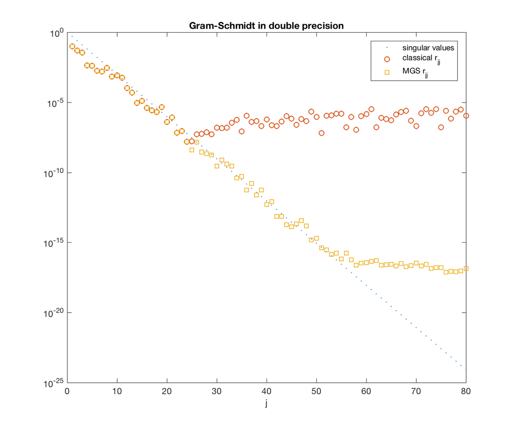

```matlab
semilogy(s,'.')
[Qc,Rc] = gs(A);  % classical
hold on, semilogy(diag(Rc),'o')
[Qm,Rm] = mgs(A); % modified
hold on, semilogy(diag(Rm),'s')
legend('singular values','classical r_{jj}','MGS r_{jj}')
title('Gram-Schmidt in double precision'), xlabel('j')
```

The modified version stays close to the line until around $10^{-16}$. This is the limit of machine precision. In the classical case the departure is closer to $10^{-8}$. We can get a little more information by recasting the problem into "single precision," which has a limit of about $10^{-8}$ relative precision.

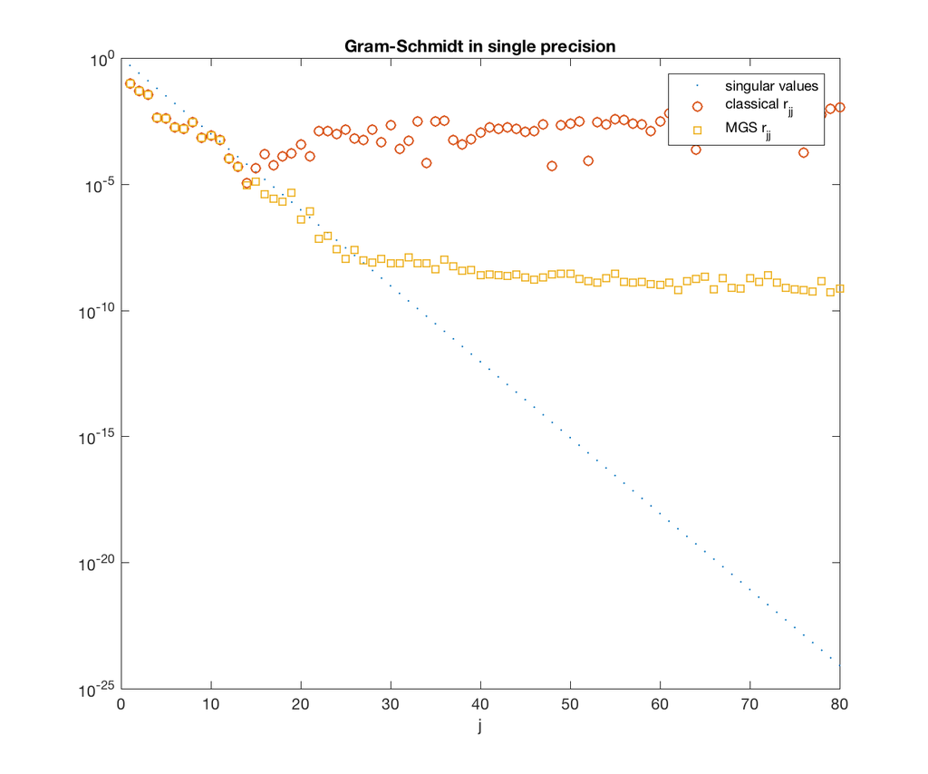

```matlab
semilogy(s,'.')
[Qc,Rc] = gs(single(A));  % classical
hold on, semilogy(diag(Rc),'o')
[Qm,Rm] = mgs(single(A)); % modified
hold on, semilogy(diag(Rm),'s')
legend('singular values','classical r_{jj}','MGS r_{jj}')
title('Gram-Schmidt in single precision'), xlabel('j')
```

A reasonable hypothesis (based on two data points) is that roundoff at precision $\epsilon$ affects MGS at the level $O(\epsilon)$, but classical GS at $O(\sqrt{\epsilon})$.

## Loss of orthogonality

A different sort of instability remains in the MGS algorithm. It can be seen in a $2\times 2$ toy example. Mine is different from the text's, but constructed using the same principle: the columns of $A$ are nearly parallel.

```matlab
A = [pi, sqrt(2); 355/113, sqrt(2)]
```

```
A =

    3.1416    1.4142
    3.1416    1.4142
```

When we subtract off the projection of the second column onto the first, the remainder is quite small (relative to the original components).

```matlab
Q = A(:,1)/norm(A(:,1));
v = A(:,2) - Q(:,1)*(Q(:,1)'*A(:,2))
```

```
v =

   1.0e-07 *

    0.6004
   -0.6004
```

Of the original 16 significant digits, about 7 have been canceled out in subtraction, never to return.

```matlab
Q(:,2) = v/norm(v);
norm(Q'*Q - eye(2))
```

```
ans =

   3.7693e-09
```

Much later, when we start doing iterative methods, we'll be coming back to the MGS algorithm. This loss of orthogonality is so important that practical implementations take measures to re-orthogonalize their results regularly.